# Análisis del índice de desarrollo humano

Autor/a

Lara Roselyn

## 1. Descarga de Datos

Mediante el paquete https://tidy-intelligence.github.io/r-owidapi/ con la función “owidapi”, se descargan los datos del Indice de Desarrollo Humano para Argentina. Colombia, España y Venezuela.

### 1.1. Descargamos los datos

Descargamos datos del índice de Desarrollo Humano ‘human-development-index’ para los paìses “AR”, ‘COL’, ‘ESP’, ‘VEN’.

```r
library(owidapi)

owid_get('human-development-index') #Visualizamos los datos del paquete
```

```
# A tibble: 6,603 × 4
   entity_name entity_id  year hdi__sex_total
   <chr>       <chr>     <int>          <dbl>
 1 Afghanistan AFG        1990          0.285
 2 Afghanistan AFG        1991          0.291
 3 Afghanistan AFG        1992          0.301
 4 Afghanistan AFG        1993          0.311
 5 Afghanistan AFG        1994          0.305
 6 Afghanistan AFG        1995          0.329
 7 Afghanistan AFG        1996          0.334
 8 Afghanistan AFG        1997          0.338
 9 Afghanistan AFG        1998          0.338
10 Afghanistan AFG        1999          0.347
# ℹ 6,593 more rows
```

### 1.2. Datos del IDH los países seleccionados

```r
indice_desarrollo_hum <- owid_get('human-development-index',
  entities = c('ARG', 'COL', 'ESP', 'VEN'))

datatable(indice_desarrollo_hum)
```

|  | entity_name | entity_id | year | hdi__sex_total |
| --- | --- | --- | --- | --- |
| 1 | Argentina | ARG | 1990 | 0.733 |
| 2 | Argentina | ARG | 1991 | 0.739 |
| 3 | Argentina | ARG | 1992 | 0.743 |
| 4 | Argentina | ARG | 1993 | 0.748 |
| 5 | Argentina | ARG | 1994 | 0.753 |
| 6 | Argentina | ARG | 1995 | 0.754 |
| 7 | Argentina | ARG | 1996 | 0.76 |
| 8 | Argentina | ARG | 1997 | 0.768 |
| 9 | Argentina | ARG | 1998 | 0.772 |
| 10 | Argentina | ARG | 1999 | 0.783 |

[output cut: 126 more lines]

### 1.3. Removemos la columna “entity_id”

```r
#Removemos la columna que hace referencia al id del país.

indice_desarrollo_hum <- indice_desarrollo_hum %>%
  select(-entity_id)

datatable(indice_desarrollo_hum)
```

|  | entity_name | year | hdi__sex_total |
| --- | --- | --- | --- |
| 1 | Argentina | 1990 | 0.733 |
| 2 | Argentina | 1991 | 0.739 |
| 3 | Argentina | 1992 | 0.743 |
| 4 | Argentina | 1993 | 0.748 |
| 5 | Argentina | 1994 | 0.753 |
| 6 | Argentina | 1995 | 0.754 |
| 7 | Argentina | 1996 | 0.76 |
| 8 | Argentina | 1997 | 0.768 |
| 9 | Argentina | 1998 | 0.772 |
| 10 | Argentina | 1999 | 0.783 |

[output cut: 126 more lines]

## 2. Creación de Variable Categórica de IDH

Mediante la función `mutate`, creamos una variable categórica para evaluar cuáles son los valores por encima del promedio del IDH para los países seleccionados.”

|  | entity_name | year | hdi__sex_total | nivel_indice |
| --- | --- | --- | --- | --- |
| 1 | Argentina | 1990 | 0.733 | bajo_indice |
| 2 | Argentina | 1991 | 0.739 | bajo_indice |
| 3 | Argentina | 1992 | 0.743 | bajo_indice |
| 4 | Argentina | 1993 | 0.748 | bajo_indice |
| 5 | Argentina | 1994 | 0.753 | bajo_indice |
| 6 | Argentina | 1995 | 0.754 | bajo_indice |
| 7 | Argentina | 1996 | 0.76 | bajo_indice |
| 8 | Argentina | 1997 | 0.768 | bajo_indice |
| 9 | Argentina | 1998 | 0.772 | bajo_indice |
| 10 | Argentina | 1999 | 0.783 | alto_indice |

[output cut: 126 more lines]

El análisis del Índice de Desarrollo Humano (IDH) para Argentina, Colombia, España y Venezuela, en relación con el promedio de este conjunto de naciones, revela patrones de desarrollo diversos y significativos a lo largo del tiempo.

Argentina ha demostrado una trayectoria de desarrollo sólida. A partir de 1999, sus índices de IDH se han mantenido consistentemente por encima del promedio del grupo, lo que sugiere un avance sostenido en sus indicadores de bienestar y calidad de vida.

Por su parte, Colombia exhibe una notable mejora en años recientes. Específicamente en 2019, 2022 y 2023, su IDH superó el promedio del conjunto de países. Esta tendencia indica un progreso significativo y una mejoría en las condiciones de desarrollo humano del país en el periodo más reciente.

En el caso de España, se observa un rendimiento generalmente elevado. Aunque sus índices más bajos dentro del periodo analizado se registraron en 1990 y 1991, su IDH ha sido consistentemente alto en los demás años. De hecho, España destaca como el país con el IDH más elevado de todo el conjunto analizado, lo que subraya su avanzado nivel de desarrollo humano.

Por último, Venezuela, el último país de nuestro análisis, presenta una situación menos favorable y preocupante. Su IDH se ha mantenado por debajo del promedio del grupo en todos los años observados, posicionándose como el país con el índice más bajo dentro de este conjunto de naciones. Este patrón constante sugiere desafíos persistentes en sus dimensiones de desarrollo humano.

## 3. Gráficos con ggplot2:

### 3.1. Geom_bar: Total de Observaciones por país.

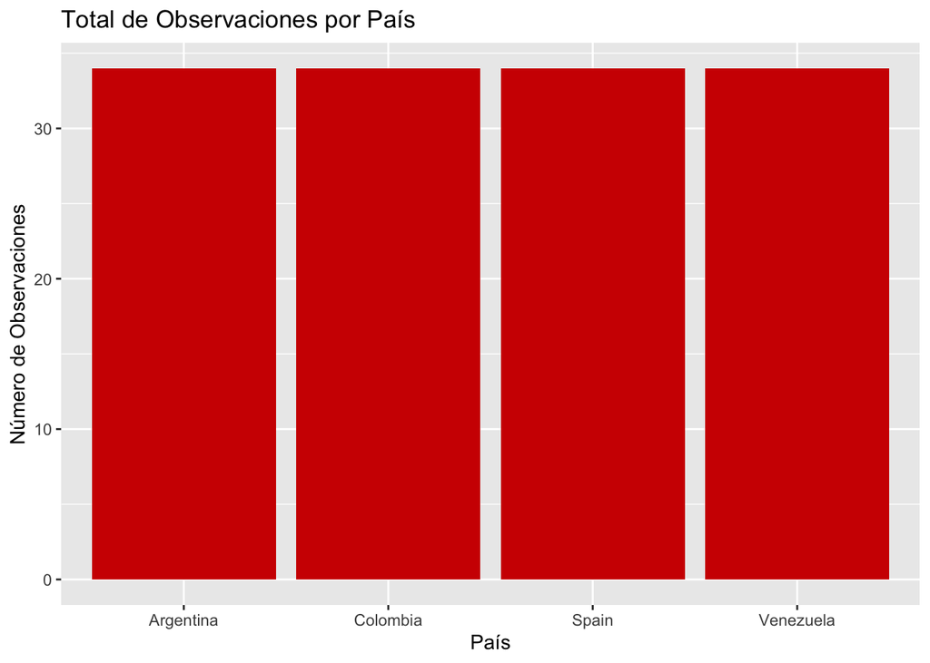

Lo más llamativo y relevante de este gráfico es la idéntica altura de todas las barras. Esto indica que el número de observaciones es prácticamente el mismo para Argentina, Colombia, España y Venezuela (34 observaciones). Lo que nos sugiere que, en el contexto de lo que se está midiendo, la cantidad de datos o eventos registrados es consistente para estas cuatro naciones.

### 3.2. Geom_boxplot: Boxplot del IDH por país:

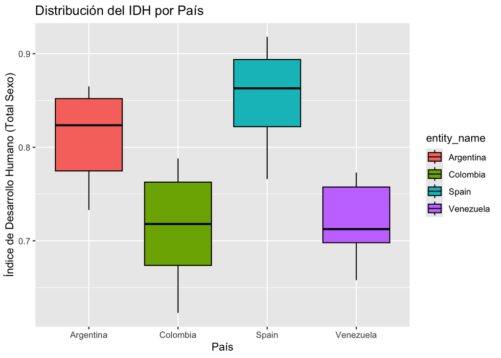

**Argentina (Rojo) y Colombia (Verde):** Segundo IDH más alto, pero con mayor dispersión. La mediana de Argentina, ubicándose en el segundo lugar después de España. Sus bigotes también cubren un rango más amplio. La caja de Colombia es la más alta y sus bigotes son los más extendidos hacia abajo, lo que indica la mayor variabilidad o dispersión en sus valores de IDH dentro de este grupo. Esto podría significar mayores fluctuaciones históricas en su IDH o una mayor diversidad en las observaciones utilizadas.

### 3.3. Geom_histogram: Histograma de IDH

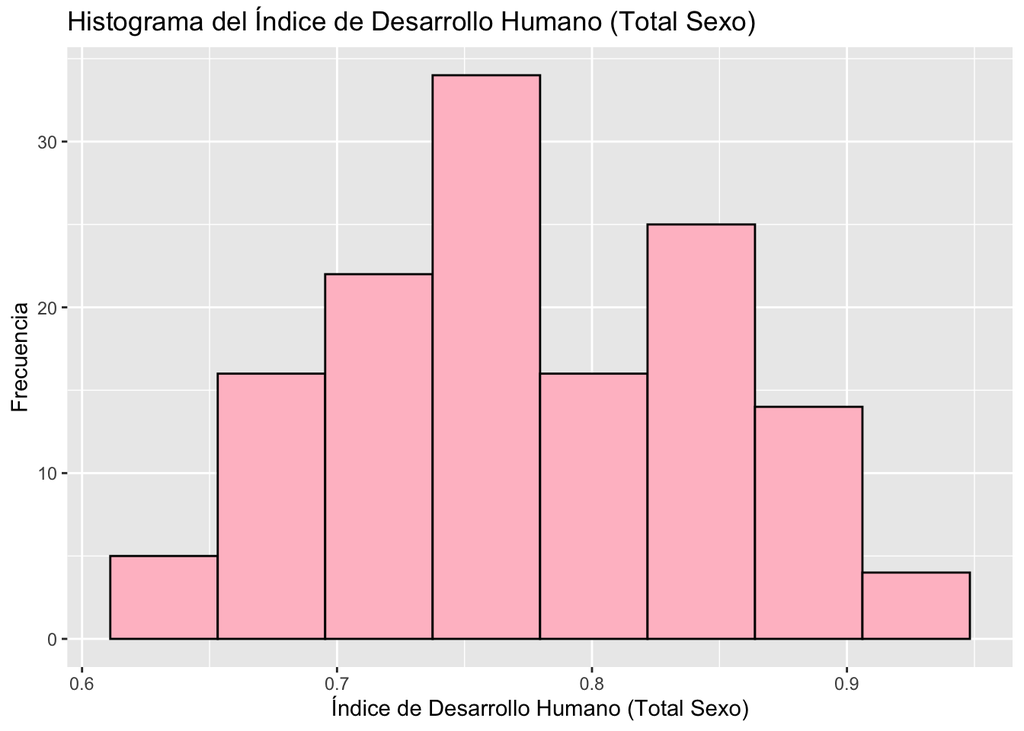

El gráfico sugiere que la mayoría de los valores del IDH en este conjunto de datos se agrupan en un rango medio a medio-alto, con una distribución que tiende a ser en alrededor de 0.7-0.8 y se extiende de forma más dispersa hacia los valores más bajos y más altos.

### 3.4. Geom_histogram: Histograma del IDH por país

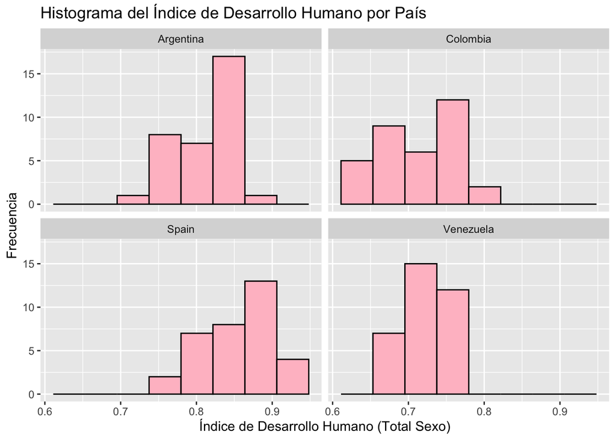

**Argentina**: La distribución de Argentina está claramente sesgada hacia la derecha (o sesgo negativo)

**Colombia:** La distribución de Colombia parece más simétrica o ligeramente sesgada a la izquierda (o sesgo positivo), con un pico alrededor de 0.75-0.78

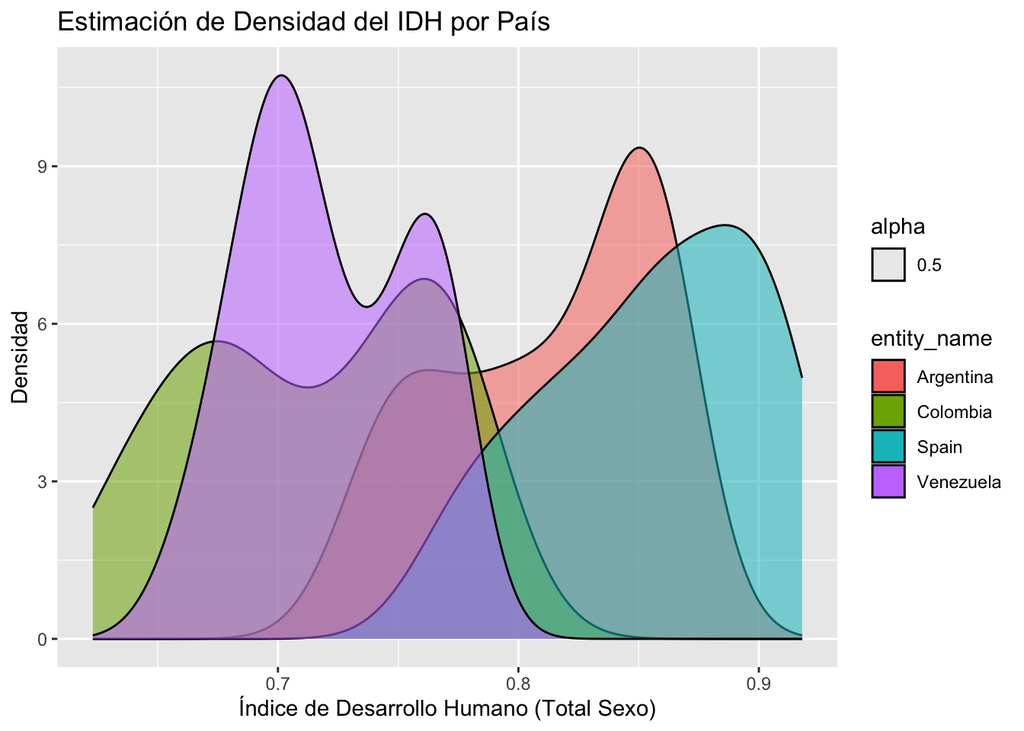

### 3.6. Geom_line: Evolución del IDH por país.

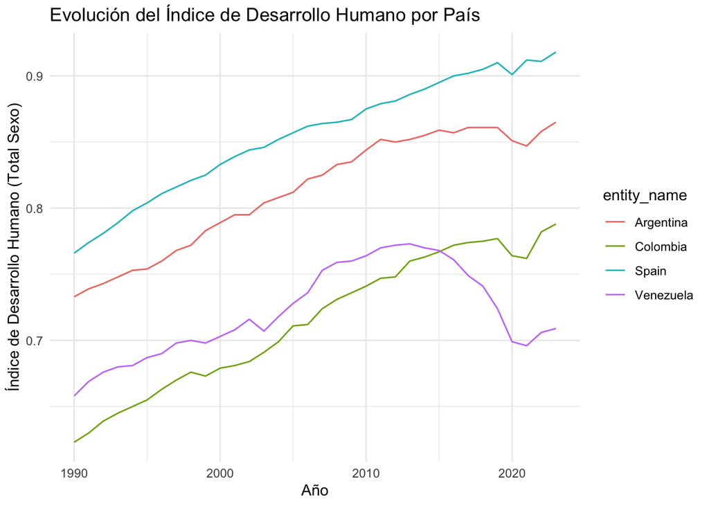

## 4. Tabla en GT

Valores maximos del IDH por país

| País | Año | IDH | Nivel de índice |
| --- | --- | --- | --- |
| Argentina | 2023 | 0.865 | alto_indice |
| Colombia | 2023 | 0.788 | alto_indice |
| Spain | 2023 | 0.918 | alto_indice |
| Venezuela | 2013 | 0.773 | bajo_indice |

Se observa como, mientras que España, Argentina y Colombia han logrado mantener o mejorar sus niveles de desarrollo humano a lo largo del tiempo, Venezuela ha experimentado una regresión crítica que la ha llevado a los niveles más bajos de este grupo, con serias implicaciones para el bienestar de su población.

## 5. Conclusiones.

El análisis del Índice de Desarrollo Humano, usando la función de “owidapi” para Argentina, Colombia, España y Venezuela, basado en datos uniformes a lo largo del tiempo, revela trayectorias de desarrollo marcadamente diferentes.

España consistentemente lidera en IDH, mostrando una distribución de rango más alto y un crecimiento sostenido que la llevó a su pico de 0.918 en 2023. Argentina sigue un patrón similar de alto desarrollo, aunque con mayor dispersión en sus valores, alcanzando un máximo de 0.865 en 2023. Colombia, por su parte, ha exhibido un progreso constante y ascendente, logrando superar a Venezuela en los últimos años y llegando a su máximo de 0.788 en 2023.

En marcado contraste, Venezuela, tras un crecimiento inicial hasta 2013 (cuando alcanzó su máximo de 0.773), sufrió una caída drástica y prolongada en su IDH, reflejada en una distribución bimodal y terminando el período como el país con el IDH más bajo